# 01a ICB - Prep Domain Numerator

J Andres Gannon

May 19, 2020

This document loads in the newly created ICB data that identifies the military domains used by each crisis-actor.

# 1 Load

Start by loading the cleaned ICB data. For this version of the data, each row is a crisis-actor and each column is a dummy variable for a military domain

We can examine distributions of the numeric variables to identify outliers or problems in data quality. Everything looks largely correct

```
##     variable q_zeros p_zeros q_na p_na q_inf p_inf      type unique
## 1     crisno       0    0.00    0 0.00     0     0   numeric    475
## 2      actor       0    0.00   38 0.48     0     0 character    412
## 3 event_type       0    0.00   46 0.58     0     0 character      3
## 4       land    3865   48.78    0 0.00     0     0   numeric      2
## 5        air    6645   83.86    0 0.00     0     0   numeric      2
## 6        sea    7069   89.21    0 0.00     0     0   numeric      2
## 7        wmd    7689   97.03    0 0.00     0     0   numeric      2
## 8      space    7895   99.63    0 0.00     0     0   numeric      2
## 9      cyber    7917   99.91    0 0.00     0     0   numeric      2
```

|  | variable | q_zeros | p_zeros | q_na | p_na | q_inf | p_inf | type | unique |
| --- | --- | --- | --- | --- | --- | --- | --- | --- | --- |
| 1 | crisno | 0 | 0 | 0 | 0 | 0 | 0 | numeric | 475 |
| 2 | actor | 0 | 0 | 38 | 0.48 | 0 | 0 | character | 412 |
| 3 | event_type | 0 | 0 | 46 | 0.58 | 0 | 0 | character | 3 |
| 4 | land | 3865 | 48.78 | 0 | 0 | 0 | 0 | numeric | 2 |
| 5 | air | 6645 | 83.86 | 0 | 0 | 0 | 0 | numeric | 2 |
| 6 | sea | 7069 | 89.21 | 0 | 0 | 0 | 0 | numeric | 2 |
| 7 | wmd | 7689 | 97.03 | 0 | 0 | 0 | 0 | numeric | 2 |
| 8 | space | 7895 | 99.63 | 0 | 0 | 0 | 0 | numeric | 2 |
| 9 | cyber | 7917 | 99.91 | 0 | 0 | 0 | 0 | numeric | 2 |

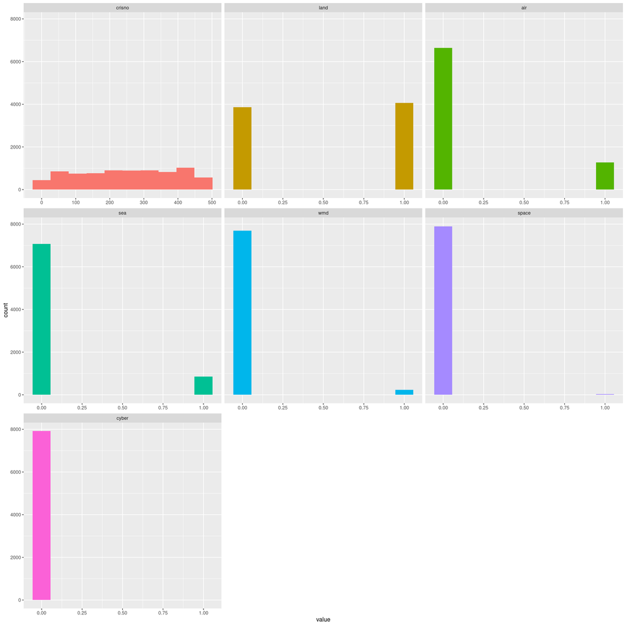

# 2 Prep ICB domain data

## 2.1 Reshape

We need the ICB domains data with each row being a crisis actor and each column is a dummy for type-domain

Each domain can be “used” by an actor as either a thought, speech, action. We want to disaggregate those because they are not the same. That can also tell us about escalation patterns. We use the same process to convert the wikipedia URL actor names into strings that can be matched to GW country codes and qcodes

We then convert the event_type column into the appropriate dummies

## 2.2 Add year and crisis name

These variables are helpful for getting the correct actor codes, since they change over time, and just generally identifying the crises

## 2.3 Fix actor names

Actor names are currently coded using their wikipedia URL. We want to convert that to the corresponding wikidata names with Q codes

# 3 Add external variables

## 3.1 Qcodes

We now add qcodes for each actor which is their unique identifier from wikidata. These have been manually collected for each domain crisis-actor. The table shown below are all the non-Gleditsch Ward country crisis-actors for which we have domain data. The table should represent international bodies and non-state actors

|  | actor | qcode |
| --- | --- | --- |
| 1 | abkhazia | Q23334 |
| 2 | abu nidal organization | Q1638579 |
| 3 | african national congress | Q83162 |
| 4 | african party for the independence of guinea and cape verde | Q776352 |
| 5 | african union | Q7159 |
| 6 | african, caribbean and pacific group of states | Q294278 |
| 7 | al-qaeda | Q34490 |
| 8 | åland islands | Q5689 |
| 9 | algiers | Q3561 |
| 10 | all-african peoples' conference | Q2748707 |

[output cut: 167 more lines]

## 3.2 GW country codes

While in theory the Qcodes should be matched to GW country codes in the previous dataset, they are not matched by year which produces problems for entities that change code over time or should only be considered states during certain time periods

|  | crisno | year | actor | qcode | gwcode | gwname | gwcode_date | gwname_date |
| --- | --- | --- | --- | --- | --- | --- | --- | --- |
| 1 | 145 | 1954 | vietnam | Q881 | 815 | VNM | 816 | DRV |
| 2 | 180 | 1961 | vietnam | Q881 | 815 | VNM | 816 | DRV |
| 3 | 210 | 1964 | vietnam | Q881 | 815 | VNM | 816 | DRV |
| 4 | 258 | 1974 | vietnam | Q881 | 815 | VNM | 816 | DRV |
| 5 | 284 | 1977 | vietnam | Q881 | 815 | VNM | 816 | DRV |
| 6 | 298 | 1978 | vietnam | Q881 | 815 | VNM | 816 | DRV |
| 7 | 351 | 1984 | vietnam | Q881 | 815 | VNM | 816 | DRV |
| 8 | 352 | 1984 | vietnam | Q881 | 815 | VNM | 816 | DRV |
| 9 | 353 | 1984 | vietnam | Q881 | 815 | VNM | 816 | DRV |
| 10 | 371 | 1987 | vietnam | Q881 | 815 | VNM | 816 | DRV |

[output cut: 4 more lines]

Now that that’s cleaned, the list of crisis-actors without a GW code should only refer to non-state or suprastate actors

|  | actor | gwname | gwcode |
| --- | --- | --- | --- |
| 1 | abkhazia |  |  |
| 2 | abu nidal organization |  |  |
| 3 | african national congress |  |  |
| 4 | african party for the independence of guinea and cape verde |  |  |
| 5 | african union |  |  |
| 6 | african, caribbean and pacific group of states |  |  |
| 7 | al-qaeda |  |  |
| 8 | åland islands |  |  |
| 9 | algiers |  |  |
| 10 | all-african peoples' conference |  |  |

[output cut: 167 more lines]

# 4 Sort

We re-sort the columns and make sure they are appropriately named

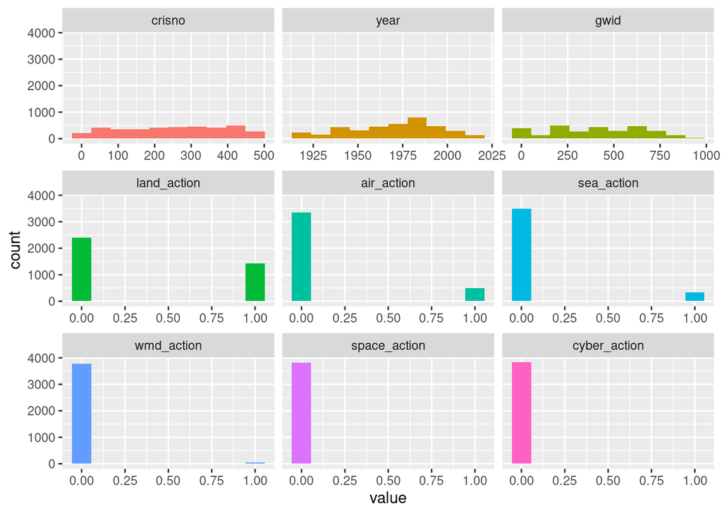

# 5 Fix edge cases

## 5.1 Actor coding

Some actors still have GW codes even though they do not refer to the country. We fix those manually

|  | actor | gwname | gwid |
| --- | --- | --- | --- |
| 1 | allies of world war i |  |  |
| 2 | organization of american states |  |  |
| 3 | bolsheviks |  |  |
| 4 | central powers |  |  |
| 5 | allies of world war ii |  |  |
| 6 | league of nations |  |  |
| 7 | white movement |  |  |
| 8 | united nations |  |  |
| 9 | åland islands |  |  |
| 10 | house of lorraine |  |  |

[output cut: 394 more lines]

## 5.2 Domain coding

Some action codings have to be fixed. We double check all action codings and manually fix ones that were errors by the original coders. We start by examining the less common domains of WMD, space, and cyber

# 6 Save

Save final version of the new data